# Prediction of patients' readmission to hospital

## (Binary Classification Problem)

### Overview

For this project, the dataset used is the [UCI dataset](https://archive-beta.ics.uci.edu/ml/datasets/diabetes+130+us+hospitals+for+years+1999+2008). The dataset (diabetic_data.csv) represents 10 years (1999-2008) of clinical care at 130 US hospitals and integrated delivery networks.

The dataset contains 50 explanatory variables that describe the patient and hospital outcomes. We predict the readmission of a patient discharged from a hospital within 30 days, based on the given dataset. The data is preprocessed, split into a train and test data set for training and testing purposes. The training and test set have been taken from [this folder](https://drive.google.com/drive/folders/1Ap_ONx3lm2MyHJVlex2jypLi05mhh-xm?usp=sharing).

### Goal:

The primary objective of this project's predictive analysis is to build a binary classification model that can predict early (<30 days) readmission given the patient’s features i.e. - **To predict whether a patient will be readmitted in hospital given that they have been discharged from the hospital in the last 30 days**.

### Workflow:

We will start with cleaning and preprocessing the data provided. Post this, the features are selected and the class imbalance in the dataset is handled using various techniques. Finally, various machine learning models are trained and evaluated on the validation set to evaluate their performance and optimize to get the best performance on our test set. The best of the optimized model(s) is/are chosen and finally evaluated on the heldout test set.

- Dataset description
- Importing libraries & packages
- Reading the dataset
- Dataset exploration
- Data preprocessing
- Feature Selection
- Imbalance dataset handling
- Model Building
- Model Selection: Hyperparameter Tuning
- Model Selection & Evaluation
- Conclusion

### Dataset description

#### Each row of the dataset represents information about a patient and their respective hospital related outcome.

**Here is a short description of each of the dataset's features:**

- `encounter_id` - Unique identifier of a specific encounter
- `patient_nbr` - Unique identifier of a specific patient
- `race` - Patient's race (Caucasian, Asian, African American, Hispanic, or other)
- `gender` - Patient's gender (Male or Female or unknown/invalid)
- `age` - Patient's age group (10 year intervals such as 0-10 or 20-30 etc.)
- `weight` - Patient's weight groups in intervals of 25 (in pounds)
- `admission_type_id` - Integer identifier corresponding to 8 distinct values (1 - 8)
- `discharge_disposition_id` - Integer identifier corresponding to 26 distinct values indicating where the patient is at the conclusion of an encounter
- `admission_source_id` - Integer identifier corresponding to 17 distinct values for the source of patient's admission
- `time_in_hospital` - Integer representing no. of days patient was admitted in hospital for
- `payer_code` - Integer identifier corresponding to 18 distinct values and few missing ones
- `medical_specialty` - Integer identifier of a specialty of the admitting doctor, corresponding to 73 distinct values
- `num_lab_procedures` - Integer value for number of lab procedures performed during the encounter
- `num_procedures` - Integer value for number of procedures performed during the encounter (other than lab tests)
- `num_medications` - Number of distinct medications administered during the encounter
- `number_outpatient` - Number of patient's outpatient visits before the encounter
- `number_emergency` - Number of patient's emergency visits before the encounter
- `number_inpatient` - Number of patient's inpatient visits before the encounter
- `diag_1` - The primary diagnosis type (coded as first three digits as per ICD9 coding); 717 distinct values
- `diag_2` - The secondary diagnosis type (coded as first three digits as per ICD9 coding); 749 distinct values
- `diag_3` - The primary diagnosis type (coded as first three digits as per ICD9 coding); 790 distinct values
- `number_diagnoses` - Number of diagnoses for a patient
- `max_glu_serum` - indicates the range of the result or whether the test was not taken (Glucose serum test)
- `A1Cresult` - indicates the range of the result or whether the test was not taken (A1c test)
- `change` - indicates whether there was a change in diabetic medications for the patient
- `diabetesMed` - indicates whether there was any diabetic medication prescribed to the patient
- `readmitted` - indicates whether an inpatient was readmitted in less than or more than 30 days or not readmitted at all
- 23 distinct kinds of drugs/medications

From the IDs_mapping.csv file, we can map the description of the coding for the following attributes as shown below:

1. `admission_type_id`
   - 1 -- Emergency
   - 2 -- Urgent
   - 3 -- Elective
   - 4 -- Newborn
   - 5 -- Not Available
   - 6 -- NULL
   - 7 -- Trauma Center
   - 8 -- Not Mapped
2. `discharge_disposition_id`
   - 1 -- Discharged to home
   - 2 -- Discharged/transferred to another short term hospital
   - 3 -- Discharged/transferred to SNF
   - 4 -- Discharged/transferred to ICF
   - 5 -- Discharged/transferred to another type of inpatient care institution
   - 6 -- Discharged/transferred to home with home health service
   - 7 -- Left AMA
   - 8 -- Discharged/transferred to home under care of Home IV provider
   - 9 -- Admitted as an inpatient to this hospital
   - 10 -- Neonate discharged to another hospital for neonatal aftercare
   - 11 -- Expired
   - 12 -- Still patient or expected to return for outpatient services
   - 13 -- Hospice / home
   - 14 -- Hospice / medical facility
   - 15 -- Discharged/transferred within this institution to Medicare approved swing bed
   - 16 -- Discharged/transferred/referred another institution for outpatient services
   - 17 -- Discharged/transferred/referred to this institution for outpatient services
   - 18 -- NULL
   - 19 -- Expired at home. Medicaid only, hospice.
   - 20 -- Expired in a medical facility. Medicaid only, hospice.
   - 21 -- Expired, place unknown. Medicaid only, hospice.
   - 22 -- Discharged/transferred to another rehab fac including rehab units of a hospital
   - 23 -- Discharged/transferred to a long term care hospital
   - 24 -- Discharged/transferred to a nursing facility certified under Medicaid but not certified under Medicare
   - 25 -- Not Mapped
   - 26 -- Unknown/Invalid
   - 27 -- Discharged/transferred to a federal health care facility
   - 28 -- Discharged/transferred/referred to a psychiatric hospital of psychiatric distinct part unit of a hospital
   - 29 -- Discharged/transferred to a Critical Access Hospital (CAH)
   - 30 -- Discharged/transferred to another Type of Health Care Institution not Defined Elsewhere
3. `admission_source_id`
   - 1 -- Physician Referral
   - 2 -- Clinic Referral
   - 3 -- HMO Referral
   - 4 -- Transfer from a hospital
   - 5 -- Transfer from a Skilled Nursing Facility (SNF)
   - 6 -- Transfer from another health care facility
   - 7 -- Emergency Room
   - 8 -- Court/Law Enforcement
   - 9 -- Not Available
   - 10 -- Transfer from critial access hospital
   - 11 -- Normal Delivery
   - 12 -- Premature Delivery
   - 13 -- Sick Baby
   - 14 -- Extramural Birth
   - 15 -- Not Available
   - 17 -- NULL
   - 18 -- Transfer From Another Home Health Agency
   - 19 -- Readmission to Same Home Health Agency
   - 20 -- Not Mapped
   - 21 -- Unknown/Invalid
   - 22 -- Transfer from hospital inpt/same fac reslt in a sep claim
   - 23 -- Born inside this hospital
   - 24 -- Born outside this hospital
   - 25 -- Transfer from Ambulatory Surgery Center
   - 26 -- Transfer from Hospice

### Importing libraries & packages

We start by importing the libraries & packages that will be used for analysis, modelling, preprocessing in the project.

```python
import numpy as np
import pandas as pd
import seaborn as sns
import matplotlib.pyplot as plt
import scipy
import time
from sklearn.impute import SimpleImputer
from sklearn.metrics import classification_report, confusion_matrix, accuracy_score, roc_auc_score,\
precision_score, recall_score,f1_score,make_scorer
from sklearn.preprocessing import StandardScaler
from sklearn.model_selection import RandomizedSearchCV
from sklearn.utils import resample
from sklearn.model_selection import train_test_split
from collections import Counter
from imblearn.over_sampling import SMOTE
from imblearn.under_sampling import RandomUnderSampler
from imblearn.over_sampling import RandomOverSampler
from sklearn.linear_model import LogisticRegression
from sklearn.ensemble import RandomForestClassifier
from sklearn.tree import  DecisionTreeClassifier
from sklearn.neighbors import KNeighborsClassifier
import sklearn.metrics as metrics
import warnings
warnings.filterwarnings('ignore')
```

### Reading the dataset

The training and test datasets are loaded in two different dataframes `df_train` and `df_test`.

For the ease of preprocessing and cleaning the data, both the datasets are merged, in order to perform preprocessing together and split the datasets to their original form post preprocessing.

The datasets will be split post preprocessing using the `encounter_id` for each of the data samples in both the datasets. Since each data sample has a unique encounter id, it is stored in two arrays to keep track of which samples were in training set and which were in the test set.

```python
# Loading the training dataset
df_train = pd.read_csv('diabetic_data_train.csv')

# Loading the test dataset
df_test = pd.read_csv('diabetic_data_test.csv')

print("Unique encounter ids in test set: ",len(df_test['encounter_id'].unique()))
print("Unique encounter ids in training set: ",len(df_train['encounter_id'].unique()))

# Storing the encounter ids for both the datasets in two separate arrays
test_ids = df_test['encounter_id'].unique()
train_ids = df_train['encounter_id'].unique()


# Merging both the datasets for preprocessing into a single dataframe
df = pd.concat([df_train,df_test], axis = 0)
df.head()
```

```
Unique encounter ids in test set:  25442
Unique encounter ids in training set:  76324
```

|  | Unnamed: 0 | encounter_id | patient_nbr | race | gender | age | weight | admission_type_id | discharge_disposition_id | admission_source_id | ... | citoglipton | insulin | glyburide-metformin | glipizide-metformin | glimepiride-pioglitazone | metformin-rosiglitazone | metformin-pioglitazone | change | diabetesMed | readmitted |
| --- | --- | --- | --- | --- | --- | --- | --- | --- | --- | --- | --- | --- | --- | --- | --- | --- | --- | --- | --- | --- | --- |
| 0 | 93634 | 338369606 | 159605546 | AfricanAmerican | Male | [70-80) | ? | 1 | 23 | 7 | ... | No | No | No | No | No | No | No | No | No | NO |
| 1 | 27698 | 90739116 | 83232054 | Caucasian | Female | [70-80) | [75-100) | 3 | 1 | 1 | ... | No | No | No | No | No | No | No | No | No | NO |
| 2 | 17488 | 64286964 | 95117913 | Caucasian | Male | [60-70) | ? | 3 | 1 | 1 | ... | No | No | No | No | No | No | No | Ch | Yes | >30 |
| 3 | 96510 | 376610012 | 136697972 | AfricanAmerican | Male | [40-50) | ? | 3 | 1 | 1 | ... | No | No | No | No | No | No | No | No | No | NO |
| 4 | 35774 | 110557278 | 2851308 | Caucasian | Male | [80-90) | ? | 1 | 1 | 6 | ... | No | No | No | No | No | No | No | No | No | NO |

5 rows × 51 columns

The training dataset has 76324 data samples and the test set has 25442.  
Together, the whole dataset has 101766 data samples with 51 features.

```python
print("Total number of columns in training dataset --> ",len(df_train.columns))
print("Total number of rows in training dataset    -->",len(df_train))
print("\nTotal number of columns in test dataset --> ",len(df_test.columns))
print("Total number of rows in test dataset    -->",len(df_test))
```

```
Total number of columns in training dataset -->  51
Total number of rows in training dataset    --> 76324

Total number of columns in test dataset -->  51
Total number of rows in test dataset    --> 25442
```

### Dataset exploration

We check the unique values for each of the attributes in order to find any unknown/missing data.

```python
for i in df.columns:
    print(i,"--> ",len(df[i].unique()),"unique values\n",df[i].unique(),"\n")
```

```
Unnamed: 0 -->  101766 unique values
 [93634 27698 17488 ... 46177 11421 52819]

encounter_id -->  101766 unique values
 [338369606  90739116  64286964 ... 142561326  47282550 155779584]

patient_nbr -->  71518 unique values
 [159605546  83232054  95117913 ...  17214336  30036699   8819190]

race -->  6 unique values
 ['AfricanAmerican' 'Caucasian' 'Hispanic' 'Other' '?' 'Asian']

gender -->  3 unique values
 ['Male' 'Female' 'Unknown/Invalid']

age -->  10 unique values
 ['[70-80)' '[60-70)' '[40-50)' '[80-90)' '[90-100)' '[10-20)' '[50-60)'
 '[20-30)' '[30-40)' '[0-10)']

weight -->  10 unique values
 ['?' '[75-100)' '[100-125)' '[50-75)' '[125-150)' '[175-200)' '[150-175)'
 '[25-50)' '[0-25)' '>200']

admission_type_id -->  8 unique values
 [1 3 6 2 5 8 4 7]

discharge_disposition_id -->  26 unique values
 [23  1  6 18  2  3  5  7 11 25  4 22 15 14 13  8 12 19 28 16 24 10 17 27
  9 20]

admission_source_id -->  17 unique values
 [ 7  1  6  4 17  5  2 22  3 20 14  9 10 11  8 13 25]

time_in_hospital -->  14 unique values
 [ 3  1  4  2 10  5 14  8 12  6  7 11  9 13]

payer_code -->  18 unique values
 ['MC' '?' 'BC' 'HM' 'UN' 'CM' 'SP' 'OG' 'MD' 'CP' 'OT' 'CH' 'PO' 'MP' 'DM'
 'WC' 'SI' 'FR']

```

[output cut: 326 more lines]

```

metformin-rosiglitazone -->  2 unique values
 ['No' 'Steady']

metformin-pioglitazone -->  2 unique values
 ['No' 'Steady']

change -->  2 unique values
 ['No' 'Ch']

diabetesMed -->  2 unique values
 ['No' 'Yes']

readmitted -->  3 unique values
 ['NO' '>30' '<30']
```

Our target variable here is `readmitted`. In order to predict a patient's readmission to the hospital, there are certain features in the dataset that are irrelevant for the predictive model.

The attributes `race`, `gender`, `weight`, `payer_code`, `medical_specialty`, `diag_1`, `diag_2`, and `diag_3` have missing/unknown values.  
We can find out the percentage of missing data for each of these attributes.

```python
def missing_val(df):
    print("% of missing values for race: ",(len(df.loc[df['race'] == '?'])/len(df))*100,"%")
    print("% of missing values for gender: ",(len(df.loc[df['gender'] == 'Unknown/Invalid'])/len(df))*100,"%")
    print("% of missing values for weight: ",(len(df.loc[df['weight'] == '?'])/len(df))*100,"%")
    print("% of missing values for payer_code: ",(len(df.loc[df['payer_code'] == '?'])/len(df))*100,"%")
    print("% of missing values for medical_specialty: ",(len(df.loc[df['medical_specialty'] == '?'])/len(df))*100,"%")
    print("% of missing values for diag_1: ",(len(df.loc[df['diag_1'] == '?'])/len(df))*100,"%")
    print("% of missing values for diag_2: ",(len(df.loc[df['diag_2'] == '?'])/len(df))*100,"%")
    print("% of missing values for diag_3: ",(len(df.loc[df['diag_3'] == '?'])/len(df))*100,"%")
    print("% of missing values for citoglipton: ",(len(df.loc[df['citoglipton'] == 'No'])/len(df))*100,"%")
    print("% of missing values for examide: ",(len(df.loc[df['examide'] == 'No'])/len(df))*100,"%")
    print("% of missing values for metformin-pioglitazone: ",(len(df.loc[df['metformin-pioglitazone'] == 'No'])/len(df))*100,"%")
    print("% of missing values for metformin-rosiglitazone: ",(len(df.loc[df['metformin-rosiglitazone'] == 'No'])/len(df))*100,"%")


print("\nMissing values in the training set:\n")
missing_val(df_train)
print("\nMissing values in the test set:\n")
missing_val(df_test)
```

```
Missing values in the training set:

% of missing values for race:  2.2378282060688646 %
% of missing values for gender:  0.003930611603165453 %
% of missing values for weight:  96.86992296001257 %
% of missing values for payer_code:  39.36900581730517 %
% of missing values for medical_specialty:  49.10906136994917 %
% of missing values for diag_1:  0.02620407735443635 %
% of missing values for diag_2:  0.36161626749122167 %
% of missing values for diag_3:  1.4163303810072847 %
% of missing values for citoglipton:  100.0 %
% of missing values for examide:  100.0 %
% of missing values for metformin-pioglitazone:  99.99868979613228 %
% of missing values for metformin-rosiglitazone:  99.99737959226455 %

Missing values in the test set:

% of missing values for race:  2.2207373634148255 %
% of missing values for gender:  0.0 %
% of missing values for weight:  96.82414904488641 %
% of missing values for payer_code:  40.12263186856379 %
% of missing values for medical_specialty:  49.001650813615285 %
% of missing values for diag_1:  0.003930508607813851 %
% of missing values for diag_2:  0.3223017058407358 %
% of missing values for diag_3:  1.3442339438723372 %
% of missing values for citoglipton:  100.0 %
% of missing values for examide:  100.0 %
% of missing values for metformin-pioglitazone:  100.0 %
% of missing values for metformin-rosiglitazone:  100.0 %
```

**We drop the following columns from our dataset because of the reasons stated:**

- `weight`: column has approximately 97% of the values missing
- `medical_specialty`: Almost 49% of the values are missing
- `Unnamed: 0`: uninformative feature
- `payer_code`: uninformative feature
- `citoglipton`: Only has 1 unique value for all data sample 'No', hence not informative feature
- `examide`: Only has 1 unique value for all data sample 'No', hence not informative feature

```python
df.drop(['weight','payer_code','Unnamed: 0','medical_specialty','citoglipton','examide'], axis=1, inplace=True)
```

**We check the frequency of patient readmissions and map each of the 3 unique possible values to appropriate encoding.**

```
Relative frequencies of patient readmissions (Training set):
NO     0.5391
>30    0.3493
<30    0.1116
Name: readmitted, dtype: float64

Relative frequencies of patient readmissions (Test set):
NO     0.5391
>30    0.3493
<30    0.1116
Name: readmitted, dtype: float64
```

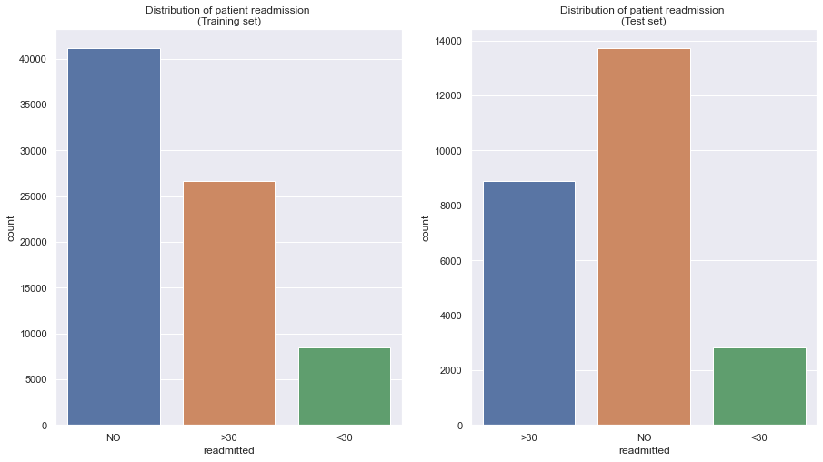

```python
print('Relative frequencies of patient readmissions (Training set):')
print(np.round(df_train['readmitted'].value_counts(normalize=True), decimals=4))

print('\nRelative frequencies of patient readmissions (Test set):')
print(np.round(df_test['readmitted'].value_counts(normalize=True), decimals=4))

fig, axes = plt.subplots(1,2)
sns.set(rc={'figure.figsize':(15,8)})
sns.countplot(df_train['readmitted'],ax=axes[0]).set_title('Distribution of patient readmission \n(Training set)')
sns.countplot(df_test['readmitted'],ax=axes[1]).set_title('Distribution of patient readmission \n(Test set)')
fig.show()

df.replace({'readmitted': {'NO': 0,'<30': 1,'>30': 0}}, inplace=True)
```

**This is clearly a case of an imbalanced dataset which we will be handling ahead.**

We create a new column `Class` for our target variable, in order to define what our two classes are.

All the <30 days readmitted patients are our positive classes (1) and all the patients who are not readmitted or are readmitted after 30 days are the negative classes (0).

```python
df['Class'] = (df.readmitted == 1).astype('int')
```

### Data preprocessing

We perform some preprocessing on the dataset in order to get it ready for training our model on.

**All the missing values are replaced by NaN for imputation purposes.**

```python
df = df.replace('?',np.nan)
df = df.replace('Unknown/Invalid',np.nan)
print(df.isnull().sum())
```

```
encounter_id                   0
patient_nbr                    0
race                        2273
gender                         3
age                            0
admission_type_id              0
discharge_disposition_id       0
admission_source_id            0
time_in_hospital               0
num_lab_procedures             0
num_procedures                 0
num_medications                0
number_outpatient              0
number_emergency               0
number_inpatient               0
diag_1                        21
diag_2                       358
diag_3                      1423
number_diagnoses               0
max_glu_serum                  0
A1Cresult                      0
metformin                      0
repaglinide                    0
nateglinide                    0
chlorpropamide                 0
glimepiride                    0
acetohexamide                  0
glipizide                      0
glyburide                      0
tolbutamide                    0
pioglitazone                   0
rosiglitazone                  0
acarbose                       0
miglitol                       0
troglitazone                   0
tolazamide                     0
insulin                        0
glyburide-metformin            0
glipizide-metformin            0
glimepiride-pioglitazone       0
metformin-rosiglitazone        0
metformin-pioglitazone         0
change                         0
diabetesMed                    0
readmitted                     0
Class                          0
dtype: int64
```

`race` has 2273 missing values which will be replaced with 'Other'.

`diag_1`, `diag_2`, `diag_3` have 21, 358, and 1423 missing values respectively, which are imputed using Simple Imputer and using the most frequent strategy for imputation.

`gender` has only 3 missing values which are also imputed using the most frequent strategy.

```python
df['race'] = df['race'].replace(np.nan,'Other')
misscol = ['diag_1','diag_2','diag_3','gender']
for col in misscol:
    imputer = SimpleImputer(missing_values=np.nan, strategy='most_frequent')
    df[col] = imputer.fit_transform(df[col].values.reshape(-1,1))[:,0]
```

The `age` is a categorical variable with 10 unique categories.

The categories are mapped for integers from 1 to 10 in order to ease the process for encoding later on.

```python
ageMap = {'[0-10)' : 1,'[10-20)' : 2,'[20-30)' : 3, '[30-40)' : 4, '[40-50)' : 5, '[50-60)' : 6,'[60-70)' : 7, '[70-80)' : 8,
'[80-90)' : 9,'[90-100)' : 10}

df['age'] = df['age'].apply(lambda x : ageMap[x])
```

The description for the `diag_1`, `diag_2`, and `diag_3` attributes are given [here](https://downloads.hindawi.com/journals/bmri/2014/781670.pdf).  
Using this description, we categorise the types of diagnosis into 9 distinct categories and map them in the three columns.

```python
df['diag_1'] = df['diag_1'].apply(lambda x : 'other' if (str(x).find('V') != -1 or str(x).find('E') != -1)
                                        else ('circulatory' if int(float(x)) in range(390, 460) or int(float(x)) == 785
                                        else     ('respiratory' if int(float(x)) in range(460, 520) or int(float(x)) == 786
                                        else     ('digestive'   if int(float(x)) in range(520, 580) or int(float(x)) == 787
                                        else     ('diabetes'    if int(float(x)) == 250
                                        else     ('injury'      if int(float(x)) in range(800, 1000)
                                        else ('musculoskeletal' if int(float(x)) in range(710, 740)
                                        else ('genitourinary'   if int(float(x)) in range(580, 630) or int(float(x)) == 788
                                        else ('neoplasms'       if int(float(x)) in range(140, 240)
                                        else 'other')))))))))

df['diag_2'] = df['diag_2'].apply(lambda x : 'other' if (str(x).find('V') != -1 or str(x).find('E') != -1)
                                        else ('circulatory' if int(float(x)) in range(390, 460) or int(float(x)) == 785
                                        else     ('respiratory' if int(float(x)) in range(460, 520) or int(float(x)) == 786
                                        else     ('digestive'   if int(float(x)) in range(520, 580) or int(float(x)) == 787
                                        else     ('diabetes'    if int(float(x)) == 250
                                        else     ('injury'      if int(float(x)) in range(800, 1000)
                                        else ('musculoskeletal' if int(float(x)) in range(710, 740)
                                        else ('genitourinary'   if int(float(x)) in range(580, 630) or int(float(x)) == 788
                                        else ('neoplasms'       if int(float(x)) in range(140, 240)
                                        else 'other')))))))))

df['diag_3'] = df['diag_3'].apply(lambda x : 'other' if (str(x).find('V') != -1 or str(x).find('E') != -1)
                                        else ('circulatory' if int(float(x)) in range(390, 460) or int(float(x)) == 785
                                        else     ('respiratory' if int(float(x)) in range(460, 520) or int(float(x)) == 786
                                        else     ('digestive'   if int(float(x)) in range(520, 580) or int(float(x)) == 787
                                        else     ('diabetes'    if int(float(x)) == 250
                                        else     ('injury'      if int(float(x)) in range(800, 1000)
                                        else ('musculoskeletal' if int(float(x)) in range(710, 740)
                                        else ('genitourinary'   if int(float(x)) in range(580, 630) or int(float(x)) == 788
                                        else ('neoplasms'       if int(float(x)) in range(140, 240)
                                        else 'other')))))))))
```

### Exploratory Data Analysis

Let's explore the data and try to derive any useful insights that may be helpful in our analysis and model building ahead.

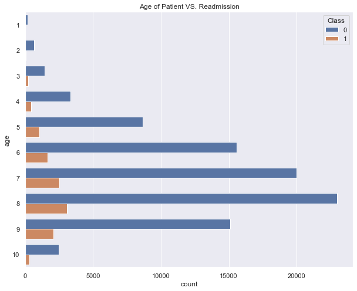

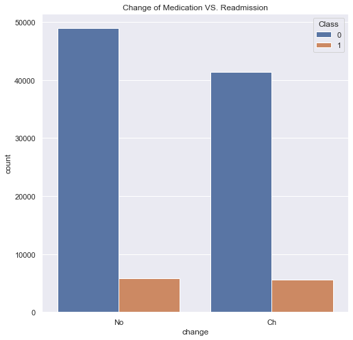

```python
fig = plt.figure(figsize=(10,8))
sns.countplot(y= df['age'], hue = df['Class']).set_title('Age of Patient VS. Readmission')

fig = plt.figure(figsize=(8,8))
sns.countplot(df['change'], hue = df['Class']).set_title('Change of Medication VS. Readmission')
```

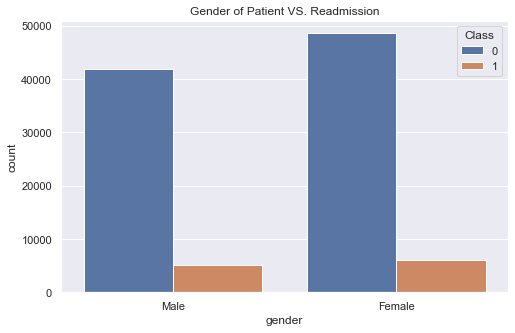

```python
fig = plt.figure(figsize=(8,5))
sns.countplot(df['gender'], hue = df['Class']).set_title("Gender of Patient VS. Readmission")
```

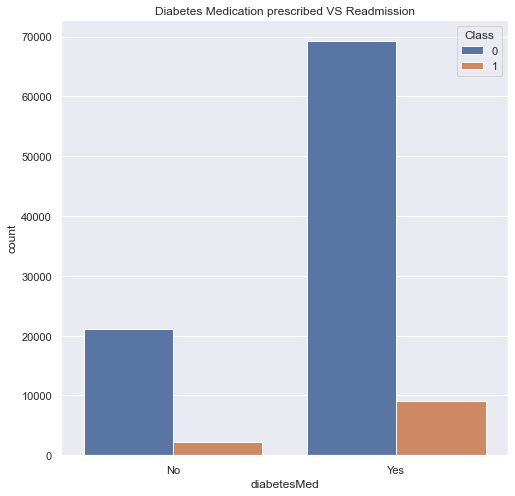

```python
#diabetic medication vs readmission

fig = plt.figure(figsize=(8,8))
sns.countplot(df['diabetesMed'], hue = df['Class']).set_title('Diabetes Medication prescribed VS Readmission')
```

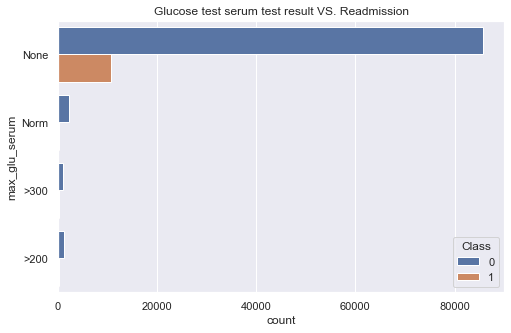

```python
#max_glue_serum vs target
fig = plt.figure(figsize=(8,5))
sns.countplot(y = df['max_glu_serum'], hue = df['Class']).set_title('Glucose test serum test result VS. Readmission')
```

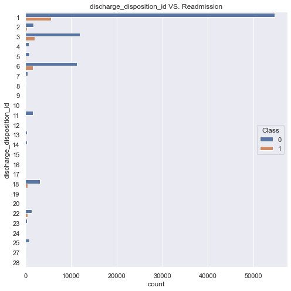

```python
#discharge_disposition_id VS. Readmission
fig = plt.figure(figsize=(8,8))
sns.countplot(y= df['discharge_disposition_id'], hue = df['Class']).set_title('discharge_disposition_id VS. Readmission')
```

### Feature Selection

After cleaning and preprocessing the data, we encode the categorical attributes & select the features to build our model with.

**Numerical features are:**

- `time_in_hospital`
- `num_lab_procedures`
- `num_procedures`
- `num_medications`
- `number_outpatient`
- `number_emergency`
- `number_inpatient`
- `number_diagnoses`

**Categorical features are:**

- `race`
- `gender`
- `max_glu_serum`
- `A1Cresult`
- `metformin`
- `repaglinide`
- `nateglinide`
- `chlorpropamide`
- `glimepiride`
- `acetohexamide`
- `glipizide`
- `glyburide`
- `tolbutamide`
- `pioglitazone`
- `rosiglitazone`
- `acarbose`
- `miglitol`
- `troglitazone`
- `tolazamide`
- `insulin`
- `glyburide-metformin`
- `glipizide-metformin`
- `glimepiride-pioglitazone`
- `change`
- `diabetesMed`
- `metformin-pioglitazone`
- `metformin-rosiglitazone`

**Numerical categorical features are:**

- `admission_type_id`
- `discharge_disposition_id`
- `admission_source_id`
- `age`
- `diag_1`
- `diag_2`
- `diag_3`

```python
# Numerical features
feat_num = ['time_in_hospital','num_lab_procedures', 'num_procedures', 'num_medications',
       'number_outpatient', 'number_emergency', 'number_inpatient','number_diagnoses']

# Categorical features
feat_cat = ['race', 'gender',
       'max_glu_serum', 'A1Cresult',
       'metformin', 'repaglinide', 'nateglinide', 'chlorpropamide',
       'glimepiride', 'acetohexamide', 'glipizide', 'glyburide', 'tolbutamide',
       'pioglitazone', 'rosiglitazone', 'acarbose', 'miglitol', 'troglitazone',
       'tolazamide', 'insulin','glyburide-metformin', 'glipizide-metformin',
       'glimepiride-pioglitazone','change', 'diabetesMed','metformin-pioglitazone','metformin-rosiglitazone']


# Categorical numerical features
feat_cat_num = ['admission_type_id', 'discharge_disposition_id', 'admission_source_id','age','diag_1','diag_2', 'diag_3']
```

For converting the categorical features to numbers, we will use one-hot encoding in which - a new column is generated for each unique value in that particular column. The values in the column are 1 if the sample has that unique value or it is 0 otherwise.

To generate these one-hot encoded columns, we will use the `get_dummies` function.

To avoid generating unnecessary columns, we can use the `drop_first` option, which drops the first categorical value for each column.

We know that the `get_dummies` function does not work on numerical values. In order to handle these numerical values and encode them, we can convert the numerical data to strings.

```python
df[feat_cat_num] = df[feat_cat_num].astype('str')

df_cat = pd.get_dummies(df[feat_cat + feat_cat_num],drop_first = True)


# Merge the original dataframe and the dataframe with encoded columns
df = pd.concat([df,df_cat], axis = 1)

# Storing the names of all encoded categorical column names in a list
feat_all_cat = list(df_cat.columns)
```

```python
print('Total number of features:', len(feat_num + feat_all_cat))
print('Numerical Features:',len(feat_num))
print('Categorical Features:',len(feat_all_cat))
```

```
Total number of features: 150
Numerical Features: 8
Categorical Features: 142
```

The features we will be using to build our model are these encoded columns.

We retain the `encounter_id` column so we can split the datasets to training and test set as they originally were with the exact same samples.

```python
features = feat_num + feat_all_cat
df_data = df[features + ['Class'] + ['encounter_id']]
df_data.shape
```

```
(101766, 152)
```

We split the dataframe into a training and test set based on the encounter ids we saved in their respective arrays earlier.

```python
testset = df_data['encounter_id'].isin(test_ids)
trainset = df_data['encounter_id'].isin(train_ids)

df_test = df_data[testset]
df_train = df_data[trainset]
```

```python
print("Test set proportion to the whole dataset: ",(len(df_test)/len(df_data)))
```

```
Test set proportion to the whole dataset:  0.25000491323231727
```

Now that we have split the dataset back to its original state, we can drop the `encounter_id` column from our training and test sets since it is an uninformative feature and not relevant to building our model.

```python
df_test.drop(['encounter_id'],axis=1,inplace=True)
df_train.drop(['encounter_id'],axis=1,inplace=True)
```

We have 76324 data samples in the training set and 25442 data samples in the test set post preprocessing and cleaning.

```python
print("Training set shape: ",df_train.shape)
print("Test set shape    : ",df_test.shape)
```

```
Training set shape:  (76324, 151)
Test set shape    :  (25442, 151)
```

### Imbalance dataset handling

Now that we are done with data preprocessing & cleaning, it might look like we are ready to train our model on the training set and analyse the performance. However, if we fit the training data into a predictive model and see the outcome, it is likely that we may obtain a model with high accuracy. But it is still not good. Why?

This is because we have an imbalanced dataset where there are much more negatives than positives, therefore the model might just assign all data samples as negative, which is not the goal of our predictive model.

In order to handle this imbalance, it is required to balance the data in some way to give the positives more weight.

**We will be using 2 techniques for dealing with this imbalance:**

- **Random Over-sampling:** generates more samples of the minority class to balance the overall data
- **Random Under-sampling:** removes some samples from the majority class to balance the overall data

Let us see the distribution of classes in the training set.

```
Class
0    67806
1     8518
dtype: int64
```

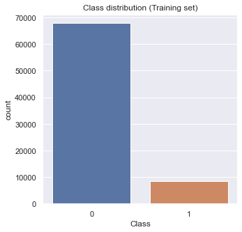

```python
print(df_train.groupby(['Class']).size())
sns.set(rc={'figure.figsize':(5,5)})
sns.countplot(df_train['Class']).set_title('Class distribution (Training set)')
```

As it is clearly observed, the positive classes are only 8518 samples out of the overall training data.

We split the training data into validation set and train set in order to build our model and assess its performance on validation set. The validation set is chosen to split from the training set based on the proportion it has to the entire dataset in order to test the model accurately.

We separate the input features of training and test set.

```python
# Separate input features and target for training set
y_train_all = df_train.Class
X_train_all = df_train.drop('Class', axis=1)

# Separate input features and target for test set
y_test = df_test.Class
X_test = df_test.drop('Class', axis=1)

# Split training data into validation and train set
X_train, X_valid, y_train, y_valid = train_test_split(X_train_all, y_train_all, test_size=0.33334206802,random_state=42)

print("Training set shape: ",X_train.shape)
print("Validation set shape: ",X_valid.shape)
print("Test set shape: ",X_test.shape)
```

```
Training set shape:  (50882, 150)
Validation set shape:  (25442, 150)
Test set shape:  (25442, 150)
```

**We will be using *SMOTE* and *RandomUnderSampler* from the *imblearn* library to perform both the sampling operations.**

#### Random Oversampling (SMOTE)

```python
print("Class distribution BEFORE oversampling: ", Counter(y_train))

smote = SMOTE(sampling_strategy='minority')

X_train_over, y_train_over = smote.fit_resample(X_train, y_train)

# Summarize class distribution
print("Class distribution AFTER oversampling : ", Counter(y_train_over))
```

```
Class distribution BEFORE oversampling:  Counter({0: 45138, 1: 5744})
Class distribution AFTER oversampling :  Counter({0: 45138, 1: 45138})
```

Now we have a balanced number of positive and negative classes which is 45138.

#### Random Undersampling

```python
print("Class distribution BEFORE undersampling: ", Counter(y_train))

# define undersampling strategy
oversample = RandomUnderSampler(sampling_strategy='majority')

# fit and apply the transform
X_train_under, y_train_under = oversample.fit_resample(X_train, y_train)

# summarize class distribution
print("Class distribution AFTER undersampling : ", Counter(y_train_under))
```

```
Class distribution BEFORE undersampling:  Counter({0: 45138, 1: 5744})
Class distribution AFTER undersampling :  Counter({0: 5744, 1: 5744})
```

Now we have a balanced number of positive and negative classes which is 5744.

We will be using both - the undersampled and the oversampled training data to train and evaluate our model and see the difference in the model performance with both.

### Model Building

Now that our dataset is completely ready to train our model, we train a few machine learning models.

**We will be evaluating and optimizing these models and ultimately choosing the best model based on performance on the test set.**

We will choose to train 3 types of classifier models and analyze their performance:

- Logistic Regression
- Decision Tree Classifier
- Random Forest Classifier

In order to evaluate our models, we utilize the following functions and metrics.

```python
def specificity_calc(y_true, y_pred, thresh):
    spec = sum((y_pred < thresh) & (y_true == 0)) /sum(y_true ==0)
    return spec

def evaluation_report(y_true, y_pred, y_pred_probs, thresh):
    auc = roc_auc_score(y_true, y_pred_probs)
    accuracy = accuracy_score(y_true, (y_pred > thresh))
    recall = recall_score(y_true, (y_pred > thresh))
    precision = precision_score(y_true, (y_pred > thresh))
    specificity = specificity_calc(y_true, y_pred, thresh)
    print("Performance metrics:")
    print('AUC: %.3f'%auc)
    print('Accuracy: %.3f'%accuracy)
    print('Recall: %.3f'%recall)
    print('Precision: %.3f'%precision)
    print('Specificity: %.3f'%specificity)
    print('\n')
    return auc, accuracy, recall, precision, specificity

def ROCcurve(y_true,y_pred_probs):
    fpr, tpr, thresh = metrics.roc_curve(y_true, y_pred_probs)
    roc_auc = metrics.auc(fpr, tpr)
    plt.figure(figsize=(7,7))
    plt.style.use('seaborn')
    plt.rcParams.update({'font.size':17})
    plt.title('Receiver Operating Characteristics Curve')
    plt.plot(fpr, tpr, 'b', label = 'AUC = %0.3f' % roc_auc)
    plt.legend(loc = 'lower right')
    plt.plot([0, 1], [0, 1],'r--')
    plt.xlim([0, 1])
    plt.ylim([0, 1])
    plt.ylabel('True Positive Rate')
    plt.xlabel('False Positive Rate')
    plt.show()
```

Now that we have handled the imbalance in our training data, we will set our threshold at 0.5 for labelling a predicted data sample to be of positive class.

```python
threshold = 0.5
```

#### Logistic Regression

We will be training our model on both - the undersampled and the oversampled training data to evaluate the performance.

```python
lr_under = LogisticRegression()
lr_under.fit(X_train_under, y_train_under)

y_pred_under_valid = lr_under.predict(X_valid)
y_pred_probs_valid = lr_under.predict_proba(X_valid)[:,1]

y_pred_under_train = lr_under.predict(X_train_under)
y_pred_probs_train = lr_under.predict_proba(X_train_under)[:,1]
```

```
LOGISTIC REGRESSION (with undersampled training data)

TRAINING SET REPORT:
              precision    recall  f1-score   support

     Class 0       0.60      0.68      0.64      5744
     Class 1       0.63      0.56      0.59      5744

    accuracy                           0.62     11488
   macro avg       0.62      0.62      0.62     11488
weighted avg       0.62      0.62      0.62     11488

Performance metrics:
AUC: 0.666
Accuracy: 0.617
Recall: 0.555
Precision: 0.634
Specificity: 0.680



VALIDATION SET REPORT:
              precision    recall  f1-score   support

     Class 0       0.93      0.67      0.78     22668
     Class 1       0.18      0.56      0.27      2774

    accuracy                           0.66     25442
   macro avg       0.55      0.62      0.52     25442
weighted avg       0.84      0.66      0.72     25442

Performance metrics:
AUC: 0.664
Accuracy: 0.663
Recall: 0.565
Precision: 0.175
Specificity: 0.675
```

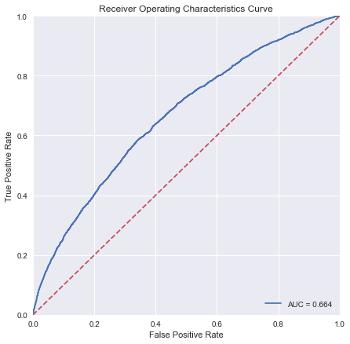

```python
print('LOGISTIC REGRESSION (with undersampled training data)\n')
targ_label = ['Class 0', 'Class 1']
print("TRAINING SET REPORT:")
print(classification_report(y_train_under, y_pred_under_train, target_names=targ_label))

lr_under_auc_train,lr_under_accuracy_train,lr_under_recall_train,lr_under_precision_train,lr_under_spec_train =\
evaluation_report(y_train_under, y_pred_under_train,y_pred_probs_train, threshold)

print("\nVALIDATION SET REPORT:")
print(classification_report(y_valid, y_pred_under_valid, target_names=targ_label))

lr_under_auc,lr_under_accuracy,lr_under_recall,lr_under_precision,lr_under_spec =\
evaluation_report(y_valid, y_pred_under_valid,y_pred_probs_valid, threshold)
ROCcurve(y_valid,y_pred_probs_valid)
```

```python
lr_over = LogisticRegression()
lr_over.fit(X_train_over, y_train_over)

y_pred_over_valid = lr_over.predict(X_valid)
y_pred_probs_valid = lr_over.predict_proba(X_valid)[:,1]

y_pred_over_train = lr_over.predict(X_train_over)
y_pred_probs_train = lr_over.predict_proba(X_train_over)[:,1]
```

```
LOGISTIC REGRESSION (with oversampled training data)

TRAINING SET REPORT:
              precision    recall  f1-score   support

     Class 0       0.88      0.95      0.91     45138
     Class 1       0.95      0.87      0.90     45138

    accuracy                           0.91     90276
   macro avg       0.91      0.91      0.91     90276
weighted avg       0.91      0.91      0.91     90276

Performance metrics:
AUC: 0.940
Accuracy: 0.908
Recall: 0.865
Precision: 0.946
Specificity: 0.951
```

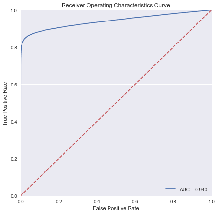

```
VALIDATION SET REPORT:
              precision    recall  f1-score   support

     Class 0       0.89      0.95      0.92     22668
     Class 1       0.16      0.08      0.11      2774

    accuracy                           0.86     25442
   macro avg       0.53      0.51      0.51     25442
weighted avg       0.81      0.86      0.83     25442

Performance metrics:
AUC: 0.560
Accuracy: 0.856
Recall: 0.079
Precision: 0.165
Specificity: 0.951
```

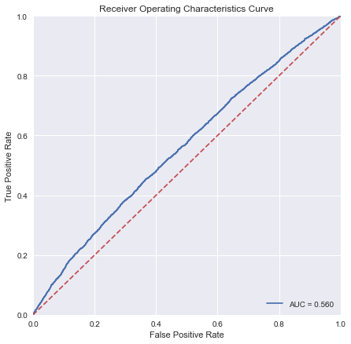

```python
print('LOGISTIC REGRESSION (with oversampled training data)\n')
targ_label = ['Class 0', 'Class 1']

print("TRAINING SET REPORT:")
print(classification_report(y_train_over, y_pred_over_train, target_names=targ_label))
lr_over_auc_train,lr_over_accuracy_train,lr_over_recall_train,lr_over_precision_train,lr_over_spec_train =\
evaluation_report(y_train_over, y_pred_over_train,y_pred_probs_train, threshold)
ROCcurve(y_train_over,y_pred_probs_train)

print("VALIDATION SET REPORT:")
print(classification_report(y_valid, y_pred_over_valid, target_names=targ_label))

lr_over_auc,lr_over_accuracy,lr_over_recall,lr_over_precision,lr_over_spec =\
evaluation_report(y_valid, y_pred_over_valid,y_pred_probs_valid, threshold)
ROCcurve(y_valid,y_pred_probs_valid)
```

#### Decision Tree Classifier

```python
tree_under = DecisionTreeClassifier(max_depth = 5)
tree_under.fit(X_train_under, y_train_under)
y_pred_under_valid = tree_under.predict(X_valid)
y_pred_probs_valid = tree_under.predict_proba(X_valid)[:,1]

y_pred_under_train = tree_under.predict(X_train_under)
y_pred_probs_train = tree_under.predict_proba(X_train_under)[:,1]
```

```
DECISION TREE CLASSIFIER (with undersampled training data)

TRAINING SET REPORT:
              precision    recall  f1-score   support

     Class 0       0.61      0.60      0.60      5744
     Class 1       0.61      0.62      0.61      5744

    accuracy                           0.61     11488
   macro avg       0.61      0.61      0.61     11488
weighted avg       0.61      0.61      0.61     11488

Performance metrics:
AUC: 0.645
Accuracy: 0.608
Recall: 0.617
Precision: 0.606
Specificity: 0.598


VALIDATION SET REPORT:
              precision    recall  f1-score   support

     Class 0       0.89      0.95      0.92     22668
     Class 1       0.16      0.08      0.11      2774

    accuracy                           0.86     25442
   macro avg       0.53      0.51      0.51     25442
weighted avg       0.81      0.86      0.83     25442

Performance metrics:
AUC: 0.652
Accuracy: 0.606
Recall: 0.643
Precision: 0.165
Specificity: 0.602
```

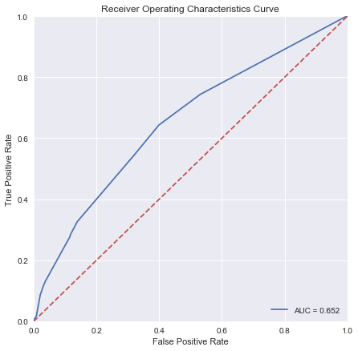

```python
print('DECISION TREE CLASSIFIER (with undersampled training data)\n')
targ_label = ['Class 0', 'Class 1']

print("TRAINING SET REPORT:")
print(classification_report(y_train_under, y_pred_under_train, target_names=targ_label))
evaluation_report(y_train_under, y_pred_under_train,y_pred_probs_train, threshold)


print("VALIDATION SET REPORT:")
print(classification_report(y_valid, y_pred_over_valid, target_names=targ_label))
dt_under_auc,dt_under_accuracy,dt_under_recall,dt_under_precision,dt_under_spec =\
evaluation_report(y_valid, y_pred_under_valid,y_pred_probs_valid, threshold)
ROCcurve(y_valid,y_pred_probs_valid)
```

```python
tree_over = DecisionTreeClassifier(max_depth = 5)
tree_over.fit(X_train_over, y_train_over)
y_pred_over_valid = tree_over.predict(X_valid)
y_pred_probs_valid = tree_over.predict_proba(X_valid)[:,1]

y_pred_over_train = tree_over.predict(X_train_over)
y_pred_probs_train = tree_over.predict_proba(X_train_over)[:,1]
```

```
DECISION TREE CLASSIFIER (with oversampled training data)

TRAINING SET REPORT:
              precision    recall  f1-score   support

     Class 0       0.72      0.83      0.77     45138
     Class 1       0.80      0.67      0.73     45138

    accuracy                           0.75     90276
   macro avg       0.76      0.75      0.75     90276
weighted avg       0.76      0.75      0.75     90276

Performance metrics:
AUC: 0.809
Accuracy: 0.752
Recall: 0.671
Precision: 0.801
Specificity: 0.833


VALIDATION SET REPORT:
              precision    recall  f1-score   support

     Class 0       0.90      0.83      0.86     22668
     Class 1       0.13      0.21      0.16      2774

    accuracy                           0.77     25442
   macro avg       0.52      0.52      0.51     25442
weighted avg       0.81      0.77      0.79     25442

Performance metrics:
AUC: 0.527
Accuracy: 0.766
Recall: 0.211
Precision: 0.134
Specificity: 0.833
```

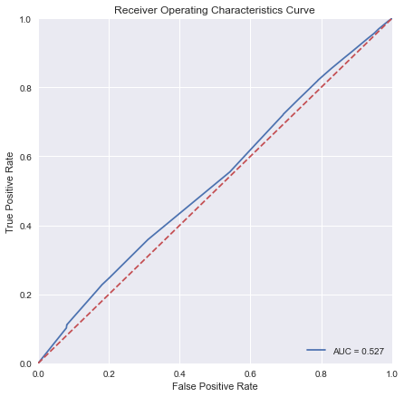

```python
print('DECISION TREE CLASSIFIER (with oversampled training data)\n')
targ_label = ['Class 0', 'Class 1']

print("TRAINING SET REPORT:")
print(classification_report(y_train_over, y_pred_over_train, target_names=targ_label))
evaluation_report(y_train_over, y_pred_over_train,y_pred_probs_train, threshold)

print("VALIDATION SET REPORT:")
print(classification_report(y_valid, y_pred_over_valid, target_names=targ_label))
dt_over_auc,dt_over_accuracy,dt_over_recall,dt_over_precision,dt_over_spec =\
evaluation_report(y_valid, y_pred_over_valid,y_pred_probs_valid, threshold)
ROCcurve(y_valid,y_pred_probs_valid)
```

#### Random Forest Classifier

```python
rf_under=RandomForestClassifier(max_depth = 10)
rf_under.fit(X_train_under, y_train_under)
y_pred_under_train = rf_under.predict(X_train_under)
y_pred_probs_train = rf_under.predict_proba(X_train_under)[:,1]

y_pred_under_valid = rf_under.predict(X_valid)
y_pred_probs_valid = rf_under.predict_proba(X_valid)[:,1]
```

```
RANDOM FOREST CLASSIFIER (with undersampled training data)

TRAINING SET REPORT:
              precision    recall  f1-score   support

     Class 0       0.69      0.78      0.73      5744
     Class 1       0.75      0.64      0.69      5744

    accuracy                           0.71     11488
   macro avg       0.72      0.71      0.71     11488
weighted avg       0.72      0.71      0.71     11488

Performance metrics:
AUC: 0.792
Accuracy: 0.712
Recall: 0.642
Precision: 0.747
Specificity: 0.782


VALIDATION SET REPORT:
              precision    recall  f1-score   support

     Class 0       0.93      0.68      0.79     22668
     Class 1       0.18      0.55      0.27      2774

    accuracy                           0.67     25442
   macro avg       0.55      0.62      0.53     25442
weighted avg       0.84      0.67      0.73     25442

Performance metrics:
AUC: 0.668
Accuracy: 0.669
Recall: 0.552
Precision: 0.176
Specificity: 0.683
```

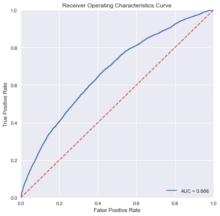

```python
print('RANDOM FOREST CLASSIFIER (with undersampled training data)\n')
targ_label = ['Class 0', 'Class 1']
print("TRAINING SET REPORT:")
print(classification_report(y_train_under, y_pred_under_train, target_names=targ_label))
evaluation_report(y_train_under, y_pred_under_train,y_pred_probs_train, threshold)

print("VALIDATION SET REPORT:")
print(classification_report(y_valid, y_pred_under_valid, target_names=targ_label))
rf_under_auc,rf_under_accuracy,rf_under_recall,rf_under_precision,rf_under_spec =\
evaluation_report(y_valid, y_pred_under_valid,y_pred_probs_valid, threshold)
ROCcurve(y_valid,y_pred_probs_valid)
```

```python
rf_over=RandomForestClassifier(max_depth = 10)
rf_over.fit(X_train_over, y_train_over)
y_pred_over_train = rf_over.predict(X_train_over)
y_pred_probs_train = rf_over.predict_proba(X_train_over)[:,1]

y_pred_over_valid = rf_over.predict(X_valid)
y_pred_probs_valid = rf_over.predict_proba(X_valid)[:,1]
```

```
RANDOM FOREST CLASSIFIER (with oversampled training data)

TRAINING SET REPORT:
              precision    recall  f1-score   support

     Class 0       0.86      0.92      0.89     45138
     Class 1       0.92      0.84      0.88     45138

    accuracy                           0.88     90276
   macro avg       0.89      0.88      0.88     90276
weighted avg       0.89      0.88      0.88     90276

Performance metrics:
AUC: 0.943
Accuracy: 0.884
Recall: 0.844
Precision: 0.917
Specificity: 0.923


VALIDATION SET REPORT:
              precision    recall  f1-score   support

     Class 0       0.89      0.92      0.91     22668
     Class 1       0.15      0.11      0.13      2774

    accuracy                           0.83     25442
   macro avg       0.52      0.52      0.52     25442
weighted avg       0.81      0.83      0.82     25442

Performance metrics:
AUC: 0.504
Accuracy: 0.834
Recall: 0.072
Precision: 0.108
Specificity: 0.927
```

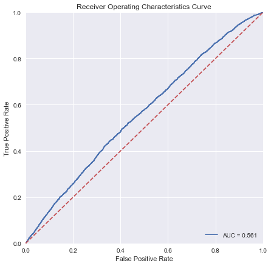

```python
print('RANDOM FOREST CLASSIFIER (with oversampled training data)\n')
targ_label = ['Class 0', 'Class 1']
print("TRAINING SET REPORT:")
print(classification_report(y_train_over, y_pred_over_train, target_names=targ_label))
evaluation_report(y_train_over, y_pred_over_train,y_pred_probs_train, threshold)

print("VALIDATION SET REPORT:")
print(classification_report(y_valid, y_pred_over_valid, target_names=targ_label))
rf_over_auc,rf_over_accuracy,rf_over_recall,rf_over_precision,rf_over_spec =\
evaluation_report(y_valid, y_pred_over,y_pred_probs, threshold)
ROCcurve(y_valid,y_pred_probs_valid)
```

### Analysis of baseline models

For analyzing our baseline models trained above, we create a dataframe with these models' evaluation results and plot them.

For our evaluation of the best model, we will be leveraging the Area under the ROC curve (AUC) metric.

**Why?**  
AUC is a good performance metric to pick the best model since it captures the essential trade off between the true positive rate and the false positive rate. The AUC indicates a model’s ability to distinguish between positive and negative classes in a dataset.  
An AUC of 1 indicates that the model made all predictions perfectly and it is a perfect model.  
An area of 0.5 represents a model as good as random. We aim to obtain an AUC > 0.5 in order to accept our model as a decent classifier.

```python
df_results = pd.DataFrame({'classifier':['LR','LR','DT','DT','RF','RF'],
                           'sampling type':['undersampled','oversampled']*3,
                          'auc':[lr_under_auc,lr_over_auc,dt_under_auc,dt_over_auc,rf_under_auc,rf_over_auc],
                          'accuracy':[lr_under_accuracy,lr_over_accuracy,dt_under_accuracy,dt_over_accuracy,\
                                      rf_under_accuracy,rf_over_accuracy],
                          'recall':[lr_under_recall,lr_over_recall,dt_under_recall,dt_over_recall,\
                                    rf_under_recall,rf_over_recall],
                          'precision':[lr_under_precision,lr_over_precision,dt_under_precision,dt_over_precision,\
                                       rf_under_precision,rf_over_precision],
                          'specificity':[lr_under_spec,lr_over_spec,dt_under_spec,dt_over_spec,rf_under_spec,rf_over_spec]})
```

```
BASELINE MODEL PERFORMANCE ON VALIDATION SET
```

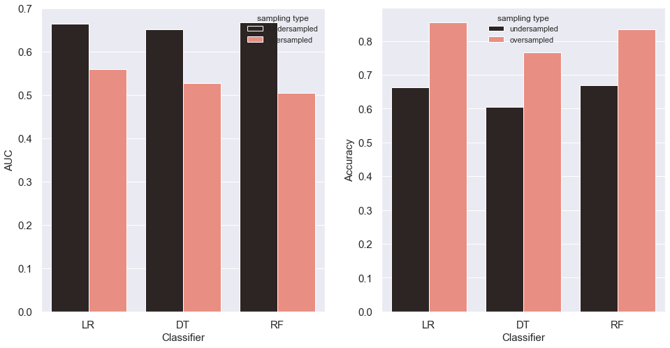

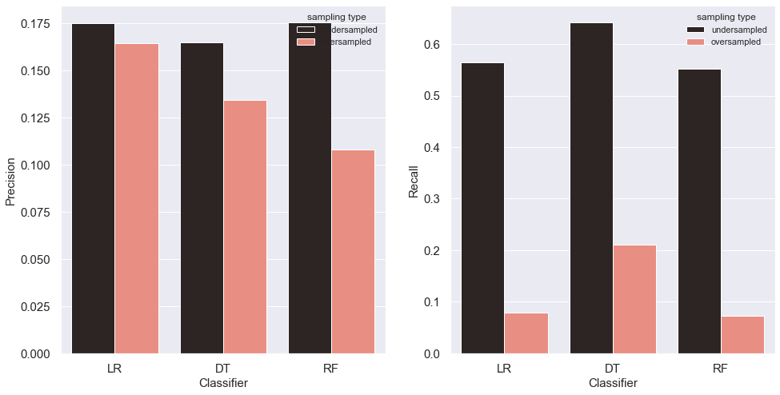

```python
print("BASELINE MODEL PERFORMANCE ON VALIDATION SET")

sns.set(style="darkgrid")

fig, axs = plt.subplots(ncols=2)
sns.set(rc={'figure.figsize':(16,8)})
ax = sns.barplot(x="classifier", y="auc", hue="sampling type", data=df_results,ax=axs[0],palette="dark:salmon")
ax.set_xlabel('Classifier',fontsize = 15)
ax.set_ylabel('AUC', fontsize = 15)
ax.tick_params(labelsize=15)

sns.set(rc={'figure.figsize':(16,8)})
ax = sns.barplot(x="classifier", y="accuracy", hue="sampling type", data=df_results,ax=axs[1],palette="dark:salmon")
ax.set_xlabel('Classifier',fontsize = 15)
ax.set_ylabel('Accuracy', fontsize = 15)
ax.tick_params(labelsize=15)

fig, axs = plt.subplots(ncols=2)
sns.set(rc={'figure.figsize':(16,8)})
ax = sns.barplot(x="classifier", y="precision", hue="sampling type", data=df_results,ax=axs[0],palette="dark:salmon")
ax.set_xlabel('Classifier',fontsize = 15)
ax.set_ylabel('Precision', fontsize = 15)
ax.tick_params(labelsize=15)

sns.set(rc={'figure.figsize':(16,8)})
ax = sns.barplot(x="classifier", y="recall", hue="sampling type", data=df_results,ax=axs[1],palette="dark:salmon")
ax.set_xlabel('Classifier',fontsize = 15)
ax.set_ylabel('Recall', fontsize = 15)
ax.tick_params(labelsize=15)
plt.show()
```

From the barplots shown above, we can make the following inferences:

**1. In terms of accuracy, training the 3 models on oversampled data gives the highest accuracy for Logistic Regression model, Decision Tree Classifier, and Random Forest Classifier. Given that our dataset is imbalanced, accuracy isn't the best measure to evaluate our models because the model may be able to predict all negative samples as negative correctly even without sampling.**

**4. We are able to obtain a recall of around 0.6 through the Decision Tree classifier. This simply means that of all the samples that were truly of the positive class, around 60% were correctly labeled by the classifier to be of that class.**

### Model Selection: Hyperparameter Tuning

The next thing we will be performing is hyperparameter tuning for the models trained. Hyperparameter tuning is primarily used to optimize the design decisions made while building our machine learning models. For example, the maximum depth of Random Forest or number of neighbors for KNN classifier. All these hyperparameters can be optimized to improve the model in some way.

We will be using a hyperparameter tuning techinque called Randomized Search in which the model randomly selects and tests all possible combinations of hyperparameters provided.

#### Logistic Regression: Hyperparameter Tuning

Since we obtained the best results for precision, recall, and AUC with undersampled data above, we will be using only undersampled data to tune the model.

```python
lr_under.get_params()
```

```
{'C': 1.0,
 'class_weight': None,
 'dual': False,
 'fit_intercept': True,
 'intercept_scaling': 1,
 'l1_ratio': None,
 'max_iter': 100,
 'multi_class': 'auto',
 'n_jobs': None,
 'penalty': 'l2',
 'random_state': None,
 'solver': 'lbfgs',
 'tol': 0.0001,
 'verbose': 0,
 'warm_start': False}
```

```python
n_jobs = range(100,1000,200)
penalty = ['l1', 'l2']
solver = ['liblinear']
C = [100, 10, 1.0, 0.1, 0.01]

random_grid = {'n_jobs':n_jobs,
              'penalty':penalty,
              'solver':solver,
              'C':C}

print(random_grid)
```

```
{'n_jobs': range(100, 1000, 200), 'penalty': ['l1', 'l2'], 'solver': ['liblinear'], 'C': [100, 10, 1.0, 0.1, 0.01]}
```

In order to use our RandomizedSearchCV function, we need an evaluator metric to evaluate the set of hyperparameters. We will use the AUC metric for our evaluation.

```python
auc_scoring = make_scorer(roc_auc_score)
```

```python
# Creating the randomized search cross-validation

lr_under_random = RandomizedSearchCV(estimator = lr_under, param_distributions = random_grid,
                               n_iter = 20, cv = 2, scoring=auc_scoring,
                               verbose = 1)
```

```python
# Fitting the Random Search model created to our data

t1 = time.time()
lr_under_random.fit(X_train_under, y_train_under)
t2 = time.time()
print(t2-t1)
```

```
Fitting 2 folds for each of 20 candidates, totalling 40 fits
106.93133902549744
```

```python
lr_under_random.best_params_
```

```
{'solver': 'liblinear', 'penalty': 'l1', 'n_jobs': 100, 'C': 1.0}
```

Let us compare our baseline model to the optimized model and check how the performance varies.

```python
lr_under = LogisticRegression()
lr_under.fit(X_train_under, y_train_under)
y_pred_under = lr_under.predict(X_valid)
y_pred_probs = lr_under.predict_proba(X_valid)[:,1]

print('LOGISTIC REGRESSION model (BASELINE)\n')
targ_label = ['Class 0', 'Class 1']

lr_base_auc,lr_base_accuracy,lr_base_recall,lr_base_precision,lr_base_spec =\
evaluation_report(y_valid, y_pred_under,y_pred_probs, threshold)
```

```
LOGISTIC REGRESSION model (BASELINE)

Performance metrics:
AUC: 0.664
Accuracy: 0.663
Recall: 0.565
Precision: 0.175
Specificity: 0.675
```

```python
y_pred_under_random = lr_under_random.best_estimator_.predict(X_valid)
y_pred_probs_random = lr_under_random.best_estimator_.predict_proba(X_valid)[:,1]

print('LOGISTIC REGRESSION model (OPTIMIZED)\n')
targ_label = ['Class 0', 'Class 1']

lr_opti_auc,lr_opti_accuracy,lr_opti_recall,lr_opti_precision,lr_opti_spec =\
evaluation_report(y_valid, y_pred_under_random,y_pred_probs_random, threshold)
```

```
LOGISTIC REGRESSION model (OPTIMIZED)

Performance metrics:
AUC: 0.671
Accuracy: 0.671
Recall: 0.555
Precision: 0.177
Specificity: 0.685
```

There are very minute differences in the model performance.  
The AUC for baseline model was 0.664 which increased to 0.671 while the precision has increased from 0.175 to 0.177, recall decreased from 0.565 to 0.555, and accuracy from 0.663 to 0.671.

We don't seem to observe any significant differences in performance.

**Let us check the next model - Decision Tree Classifier**

#### Decision Tree Classifier: Hyperparameter Tuning

```python
tree_under.get_params()
```

```
{'ccp_alpha': 0.0,
 'class_weight': None,
 'criterion': 'gini',
 'max_depth': 5,
 'max_features': None,
 'max_leaf_nodes': None,
 'min_impurity_decrease': 0.0,
 'min_impurity_split': None,
 'min_samples_leaf': 1,
 'min_samples_split': 2,
 'min_weight_fraction_leaf': 0.0,
 'random_state': None,
 'splitter': 'best'}
```

```python
criterion = ['entropy','gini']
max_depth = [1,3,6,9,10,18,23]
max_features = [2,3,6,9,10,15,19,27,35,40,78,150]
min_samples_split = [2,6,9,10]

random_grid_dt = {'criterion':criterion,
              'max_depth':max_depth,
                 'max_features':max_features,
                 'min_samples_split':min_samples_split}

print(random_grid_dt)
```

```
{'criterion': ['entropy', 'gini'], 'max_depth': [1, 3, 6, 9, 10, 18, 23], 'max_features': [2, 3, 6, 9, 10, 15, 19, 27, 35, 40, 78, 150], 'min_samples_split': [2, 6, 9, 10]}
```

```python
auc_scoring = make_scorer(roc_auc_score)

# Creating the randomized search cross-validation

tree_under_random = RandomizedSearchCV(estimator = tree_under, param_distributions = random_grid_dt,
                               n_iter = 20, cv = 2, scoring=auc_scoring,
                               verbose = 1)
```

```python
# Fitting the Random Search model created to our data

t1 = time.time()
tree_under_random.fit(X_train_under, y_train_under)
t2 = time.time()
print(t2-t1)
```

```
Fitting 2 folds for each of 20 candidates, totalling 40 fits
2.3679769039154053
```

```python
tree_under_random.best_params_
```

```
{'min_samples_split': 2,
 'max_features': 150,
 'max_depth': 6,
 'criterion': 'entropy'}
```

```python
tree_under = DecisionTreeClassifier(max_depth = 5)
tree_under.fit(X_train_under, y_train_under)
y_pred_under = tree_under.predict(X_valid)
y_pred_probs = tree_under.predict_proba(X_valid)[:,1]


print('DECISION TREE CLASSIFIER (BASELINE)\n')
targ_label = ['Class 0', 'Class 1']

dt_base_auc,dt_base_accuracy,dt_base_recall,dt_base_precision,dt_base_spec =\
evaluation_report(y_valid, y_pred_under,y_pred_probs, threshold)
```

```
DECISION TREE CLASSIFIER (BASELINE)

Performance metrics:
AUC: 0.652
Accuracy: 0.606
Recall: 0.643
Precision: 0.165
Specificity: 0.602
```

```python
y_pred_under_random = tree_under_random.best_estimator_.predict(X_valid)
y_pred_probs_random = tree_under_random.best_estimator_.predict_proba(X_valid)[:,1]

print('DECISION TREE CLASSIFIER (OPTIMIZED)\n')
targ_label = ['Class 0', 'Class 1']

dt_opti_auc,dt_opti_accuracy,dt_opti_recall,dt_opti_precision,dt_opti_spec =\
evaluation_report(y_valid, y_pred_under_random,y_pred_probs_random, threshold)
```

```
DECISION TREE CLASSIFIER (OPTIMIZED)

Performance metrics:
AUC: 0.648
Accuracy: 0.610
Recall: 0.628
Precision: 0.164
Specificity: 0.608
```

Decision Tree Classifier does not have any significant changes in performance with hyperparameter tuning.

**Let us tune the next model - Random Forest Classifier and check if there is any improvement in the model.**

#### Random Forest Classifier: Hyperparameter Tuning

```python
rf_under.get_params()
```

```
{'bootstrap': True,
 'ccp_alpha': 0.0,
 'class_weight': None,
 'criterion': 'gini',
 'max_depth': 10,
 'max_features': 'auto',
 'max_leaf_nodes': None,
 'max_samples': None,
 'min_impurity_decrease': 0.0,
 'min_impurity_split': None,
 'min_samples_leaf': 1,
 'min_samples_split': 2,
 'min_weight_fraction_leaf': 0.0,
 'n_estimators': 100,
 'n_jobs': None,
 'oob_score': False,
 'random_state': None,
 'verbose': 0,
 'warm_start': False}
```

```python
n_estimators = range(200,1000,500)
max_depth = range(5,15,5)
criterion = ['entropy']

random_grid_rf = {'n_estimators':n_estimators,
              'max_depth':max_depth,
              'criterion':criterion}

print(random_grid_rf)
```

```
{'n_estimators': range(200, 1000, 500), 'max_depth': range(5, 15, 5), 'criterion': ['entropy']}
```

```python
auc_scoring = make_scorer(roc_auc_score)

rf_random = RandomizedSearchCV(estimator = rf_under, param_distributions = random_grid_rf, n_iter = 10, cv = 2,
                               scoring=auc_scoring,verbose = 1)
```

```python
# Fitting the random search model to our data
t1 = time.time()
rf_random.fit(X_train_under, y_train_under)
t2 = time.time()
print(t2-t1)
```

```
Fitting 2 folds for each of 4 candidates, totalling 8 fits
37.010154247283936
```

```python
rf_random.best_params_
```

```
{'n_estimators': 200, 'max_depth': 10, 'criterion': 'entropy'}
```

```python
rf_under = RandomForestClassifier(max_depth = 10)
rf_under.fit(X_train_under, y_train_under)
y_pred_under = rf_under.predict(X_valid)
y_pred_probs = rf_under.predict_proba(X_valid)[:,1]

print('RANDOM FOREST CLASSIFIER (BASELINE)\n')
targ_label = ['Class 0', 'Class 1']

rf_base_auc,rf_base_accuracy,rf_base_recall,rf_base_precision,rf_base_spec =\
evaluation_report(y_valid, y_pred_under_random,y_pred_probs_random, threshold)
```

```
RANDOM FOREST CLASSIFIER (BASELINE)

Performance metrics:
AUC: 0.648
Accuracy: 0.610
Recall: 0.628
Precision: 0.164
Specificity: 0.608
```

```python
y_pred_under_random = rf_random.best_estimator_.predict(X_valid)
y_pred_probs_random = rf_random.best_estimator_.predict_proba(X_valid)[:,1]

print('RANDOM FOREST CLASSIFIER (OPTIMIZED)\n')
targ_label = ['Class 0', 'Class 1']

rf_opti_auc,rf_opti_accuracy,rf_opti_recall,rf_opti_precision,rf_opti_spec =\
evaluation_report(y_valid, y_pred_under_random,y_pred_probs_random, threshold)
```

```
RANDOM FOREST CLASSIFIER (OPTIMIZED)

Performance metrics:
AUC: 0.671
Accuracy: 0.667
Recall: 0.558
Precision: 0.176
Specificity: 0.681
```

We can visualise and plot the optimized and baseline model performance metrics:

```python
df_results = pd.DataFrame({'classifier':['LR','LR','DT','DT','RF','RF'],
                           'model_type':['optimized','baseline']*3,
                          'auc':[lr_opti_auc,lr_base_auc,dt_opti_auc,dt_base_auc,rf_opti_auc,rf_base_auc],
                          'accuracy':[lr_opti_accuracy,lr_base_accuracy,dt_opti_accuracy,dt_base_accuracy,\
                                      rf_opti_accuracy,rf_base_accuracy],
                          'recall':[lr_opti_recall,lr_base_recall,dt_opti_recall,dt_base_recall,\
                                    rf_opti_recall,rf_base_recall],
                          'precision':[lr_opti_precision,lr_base_precision,dt_opti_precision,dt_base_precision,\
                                       rf_opti_precision,rf_base_precision],
                          'specificity':[lr_opti_spec,lr_base_spec,dt_opti_spec,dt_base_spec,rf_opti_spec,rf_base_spec]})
```

```
OPTIMIZED MODEL PERFORMANCE ON VALIDATION SET
```

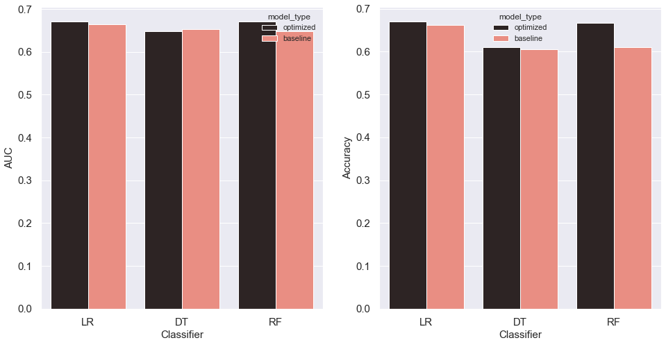

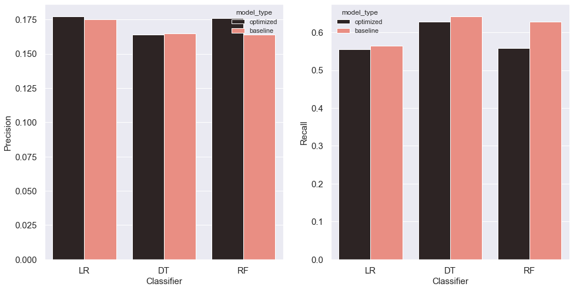

```python
print("OPTIMIZED MODEL PERFORMANCE ON VALIDATION SET")

sns.set(style="darkgrid")

fig, axs = plt.subplots(ncols=2)
sns.set(rc={'figure.figsize':(16,8)})
ax = sns.barplot(x="classifier", y="auc", hue="model_type", data=df_results,ax=axs[0],palette="dark:salmon")
ax.set_xlabel('Classifier',fontsize = 15)
ax.set_ylabel('AUC', fontsize = 15)
ax.tick_params(labelsize=15)

sns.set(rc={'figure.figsize':(16,8)})
ax = sns.barplot(x="classifier", y="accuracy", hue="model_type", data=df_results,ax=axs[1],palette="dark:salmon")
ax.set_xlabel('Classifier',fontsize = 15)
ax.set_ylabel('Accuracy', fontsize = 15)
ax.tick_params(labelsize=15)

fig, axs = plt.subplots(ncols=2)
sns.set(rc={'figure.figsize':(16,8)})
ax = sns.barplot(x="classifier", y="precision", hue="model_type", data=df_results,ax=axs[0],palette="dark:salmon")
ax.set_xlabel('Classifier',fontsize = 15)
ax.set_ylabel('Precision', fontsize = 15)
ax.tick_params(labelsize=15)

sns.set(rc={'figure.figsize':(16,8)})
ax = sns.barplot(x="classifier", y="recall", hue="model_type", data=df_results,ax=axs[1],palette="dark:salmon")
ax.set_xlabel('Classifier',fontsize = 15)
ax.set_ylabel('Recall', fontsize = 15)
ax.tick_params(labelsize=15)
plt.show()
```

### Model Selection & Evaluation

Since both - Logistic Regression model and Random Forest classifier has the best AUC out of all, we choose these 2 models as the best ones.

Let us test our best models on the test set and evaluate the performance.

```python
y_pred_under_random = lr_under_random.best_estimator_.predict(X_test)
y_pred_probs_random = lr_under_random.best_estimator_.predict_proba(X_test)[:,1]

print('LOGISTIC REGRESSION MODEL\n')

lr_opti_auc,lr_opti_accuracy,lr_opti_recall,lr_opti_precision,lr_opti_spec =\
evaluation_report(y_test, y_pred_under_random,y_pred_probs_random, threshold)
```

```
LOGISTIC REGRESSION MODEL

Performance metrics:
AUC: 0.663
Accuracy: 0.670
Recall: 0.541
Precision: 0.178
Specificity: 0.686
```

```python
y_pred_under_random = rf_random.best_estimator_.predict(X_test)
y_pred_probs_random = rf_random.best_estimator_.predict_proba(X_test)[:,1]

print('RANDOM FOREST CLASSIFIER\n')

rf_opti_auc,rf_opti_accuracy,rf_opti_recall,rf_opti_precision,rf_opti_spec =\
evaluation_report(y_test, y_pred_under_random,y_pred_probs_random, threshold)
```

```
RANDOM FOREST CLASSIFIER

Performance metrics:
AUC: 0.665
Accuracy: 0.671
Recall: 0.549
Precision: 0.180
Specificity: 0.687
```

### Conclusion

This project consisted of making a binary classifier to predict the probability that a patient would be readmitted in hospital within 30 days of discharge. On the held out test dataset, our best model had an AUC of 0.665.

Since the complete dataset was highly imbalanced, the accuracy of the model is slightly compromised in terms of predicting the sample correctly.

Using the Random Forest Classifier model, we are able to catch about 55% of the readmissions from our model that performs much better than randomly selecting patients.